# Laura Cleven: Effect of Physical (In-)Activity on Metabolic Syndrome

Author

Reinhold Kliegl

Published

September 17, 2022

# 1 Background

“Von einem metabolischen Syndrom spricht man, wenn bestimmte Erkrankungen bzw. Symptome gemeinsam auftreten. Dazu zählen in erster Linie Übergewicht, Bluthochdruck sowie Zucker- und Fettstoffwechselstörungen. Faktoren wie körperliche Inaktivität, Stress, Rauchen und Alkohol spielen bei der Entstehung mit.”

Welchen Einfluss hat körperlicher (In-)Aktivität auf die Entstehung (von Faktoren: Bluthochdruck, Diabetes, Bauchumfang nach WHO, Erhöhte Triglyceride, niedrige HDL Werte) des metabolischen Syndroms?

# 2 Preprocessing

## 2.1 RK style guide

- Random factors should be factors, not integers!
- Factors capitalized, continuous variables in lower case
- `Subj` instead of `ID`; prefix subject and item numbers with `S` and `I`
- Short variable names and factor levels, but respect tradeoff with mmemonic value
- Labels should be of equal length
- Hint: Leave out vowels in names and labels
- See Jenny Bryan’s [Naming Things](https://docplayer.net/55248970-Naming-things-prepared-by-jenny-bryan-for-reproducible-science-workshop.html)

## 2.2 Packages

```r
library(easystats)
library(tidyverse)
library(haven)
library(labelled)
library(lme4)
library(summarytools)
# respecting color vision deficiency
cbPalette <- c( "#0072B2", "#D55E00", "#009E73", "#CC79A7",
                "#F0E442", "#56B4E9", "#999999", "#E69F00")
```

## 2.3 Read and transform data

Filter: Two measures and free of all outcomes at beginning

- 6:11 - Alter
- 33:38 - Diagn_Bauch
- 65:70 - Diagn_Bluthochdruck
- 97:102 - Diagn_HDL
- 129:134 - Diagn_Triglycerin
- 161:166 - Diagn_Diabetes
- 193:198 - Summe Risikofaktoren
- 199:204 - Diagn_metSyndrom
- 236:241 - SportOGym
- 242:247 - HA_Minuten
- 248:253 - Minuten_GesamtSPORT
- 254:259 - METh_GesamtSport
- 260:265 - BMI
- 266:271 - T(aille)?
- 272:277 - Gewicht
- 280:285 - Größe
- 286:291 - Bauch
- 292:315 - Blutdruck measures
- 316:321 - HDL
- 322:327 - Tryglyc
- 339:344 - Gluc

```r
data <-
   read_sav("CLEVEN.sav") |>
   remove_labels() |>
   select(Subj=2, Sex=3, SES=19, ageSE=30, yearSE=5, 6:11, 33:38, 65:70, 97:102, 129:134, 161:166, 193:198, 199:204, 248:253, 260:265, 272:277, 280:285, 286:291, 316:321, 322:327, 339:344 ) |>
   mutate( Subj = paste0("S", str_pad(as.character(Subj), width = 5, side = "left", pad = "0")),
           Sex = factor(Sex, levels=0:1, labels=c("female", "male")),
           SES = factor(SES)
           ) |>
   relocate(Subj:SES)

colnames(data) <-  gsub("Alter", "age", colnames(data))
colnames(data) <-  gsub("Diagn_", "D", colnames(data))
colnames(data) <-  gsub("Bauch", "Bch", colnames(data))
colnames(data) <-  gsub("Bluthochdruck", "Bhd", colnames(data))
colnames(data) <-  gsub("Triglyc", "Tgl", colnames(data))
colnames(data) <-  gsub("Diabetes", "Dbt", colnames(data))
colnames(data) <-  gsub("risikofaktoren_summe", "rfsum", colnames(data))
colnames(data) <-  gsub("metSyndrom", "mS", colnames(data))
colnames(data) <-  gsub("Minuten_GesamtSPORT", "sport", colnames(data))
stview(dfSummary(data))
```

```
Switching method to 'browser'
```

```
Output file written: /var/folders/nd/l59kkqd951xdb29k4rt4yzj80000gn/T//Rtmp2lr8cV/filec5cf61ba11da.html
```

**Questions/Issues**

- Is there a composite variable “metabolic syndrome” (e.g., latent contructs based on indicators)
- There are probably better alternatives to (G)LMM, e.g., growth curve models the different lags of effects across time.
- If `rfsum` is used as dependent variable, a cumulative link mixed model should probably be used. (Is DmS == 1, if rfsum >= 3?)

## 2.4 Subset selection / wide to long format

```r
dat <-
  data |>
  select(1:65) |>
  pivot_longer(6:65, names_to=c("Variable", "year"), names_sep="_",
               names_transform=list(Variable =as.factor, year=as.integer),
               values_to="value", values_drop_na=TRUE) |>
  mutate(year = ifelse(year>90, year+1900, year+2000))


stview(dfSummary(dat))
```

```
Switching method to 'browser'
```

```
Output file written: /var/folders/nd/l59kkqd951xdb29k4rt4yzj80000gn/T//Rtmp2lr8cV/filec5cf6e3efcda.html
```

# 3 Varying covariate: `year`

## 3.1 Construct dataframe

- Criterion: `DmS` in year
- Constant covariates: `Sex`, `ageSE` (`a1,` `a2`) for `Subj`
- Varying covariate: `year` (`y1`, `y2`) for `Subj`

```r
dat_DmS_1 <-
  data |>
  select(1:4, 48:53) |>
  pivot_longer(5:10, names_prefix="DmS_", names_to= "year",
               names_transform=list(year=as.integer),
               values_to="DmS", values_drop_na=TRUE) |>
  mutate(year = ifelse(year>90, year+1900, year+2000),
         y1 = year - 2006.5,
         y2 = y1*y1,
         a1 = ageSE - 55,
         a2 = a1*a1) |>
  relocate(y1:a2, .after=year)


stview(dfSummary(dat_DmS_1))
```

```
Switching method to 'browser'
```

```
Output file written: /var/folders/nd/l59kkqd951xdb29k4rt4yzj80000gn/T//Rtmp2lr8cV/filec5cf450887be.html
```

```r
with(dat_DmS_1, table(year, DmS, Sex))
```

```
, , Sex = female

      DmS
year     0   1
  1992 223  18
  1997 170  59
  2002 148  28
  2010 116  33
  2015 191  37
  2021 174  59

, , Sex = male

      DmS
year     0   1
  1992 214  24
  1997 168  56
  2002 155  50
  2010  98  52
  2015 138  51
  2021 146  49
```

## 3.2 Plot: Year (within-subject)

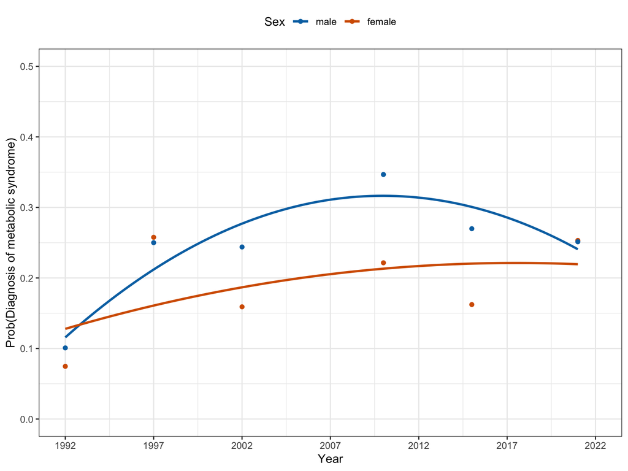

```r
dat_DmS_1 |>
  group_by(year, Sex) |>
  summarize(N=n(), pDmS = mean(DmS)) |>
  ggplot(aes(x=year, y=pDmS, group=fct_rev(Sex), color=fct_rev(Sex))) +
  geom_point() +
  geom_smooth(method="lm", formula=y~poly(x,2), se=FALSE) +
  scale_x_continuous("Year", breaks=seq(1992,2022,5)) +
  scale_y_continuous("Prob(Diagnosis of metabolic syndrome)") +
  scale_color_manual("Sex", values=cbPalette) +
  theme_bw() + theme(legend.position = "top") +
  coord_cartesian(xlim=c(1992,2022), ylim=c(0,.5))
```

## 3.3 Plot: Age at entry to study (between-subject)

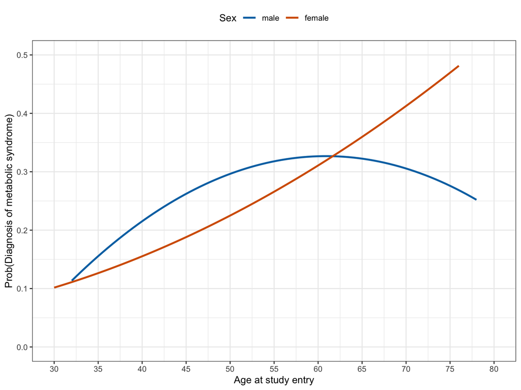

```r
dat_DmS_1 |>
  ggplot(aes(x=ageSE, y=DmS, group=fct_rev(Sex), color=fct_rev(Sex))) +
  geom_smooth(method="lm", formula=y~poly(x,2), se=FALSE) +
  scale_x_continuous("Age at study entry", breaks=seq(30,80, 5)) +
  scale_y_continuous("Prob(Diagnosis of metabolic syndrome)") +
  scale_color_manual("Sex", values=cbPalette) +
  theme_bw() + theme(legend.position = "top") +
  coord_cartesian(xlim=c(30,80), ylim=c(0,.5))
```

## 3.4 Generalized linear mixed models

### 3.4.1 *A priori* LMM

- `Sex` is between-subject
- `age` is between-subject
- `year` is within-subject

```r
contrasts(dat_DmS_1$Sex) <- contr.sum(2)

m1 <- glmer(DmS ~ 1 + Sex*(y1 + y2) + a1  + a2 + (1 | Subj), data=dat_DmS_1,
            family = binomial(link="logit"),
            control=glmerControl(calc.derivs=FALSE))

print(summary(m1),corr=FALSE)
```

```
Generalized linear mixed model fit by maximum likelihood (Laplace
  Approximation) [glmerMod]
 Family: binomial  ( logit )
Formula: DmS ~ 1 + Sex * (y1 + y2) + a1 + a2 + (1 | Subj)
   Data: dat_DmS_1
Control: glmerControl(calc.derivs = FALSE)

     AIC      BIC   logLik deviance df.resid
  2280.9   2333.2  -1131.4   2262.9     2448

Scaled residuals:
    Min      1Q  Median      3Q     Max
-1.7211 -0.3540 -0.2351 -0.1376  3.8592

Random effects:
 Groups Name        Variance Std.Dev.
 Subj   (Intercept) 3.146    1.774
Number of obs: 2457, groups:  Subj, 1084

Fixed effects:
              Estimate Std. Error z value Pr(>|z|)
(Intercept) -1.0952805  0.1619574  -6.763 1.35e-11 ***
Sex1        -0.4866713  0.1264586  -3.848 0.000119 ***
y1           0.0479605  0.0070992   6.756 1.42e-11 ***
y2          -0.0042716  0.0008386  -5.094 3.51e-07 ***
a1           0.0313808  0.0162030   1.937 0.052779 .
a2          -0.0014889  0.0008825  -1.687 0.091596 .
Sex1:y1      0.0003120  0.0070520   0.044 0.964709
Sex1:y2      0.0021635  0.0008325   2.599 0.009355 **
---
Signif. codes:  0 '***' 0.001 '**' 0.01 '*' 0.05 '.' 0.1 ' ' 1
```

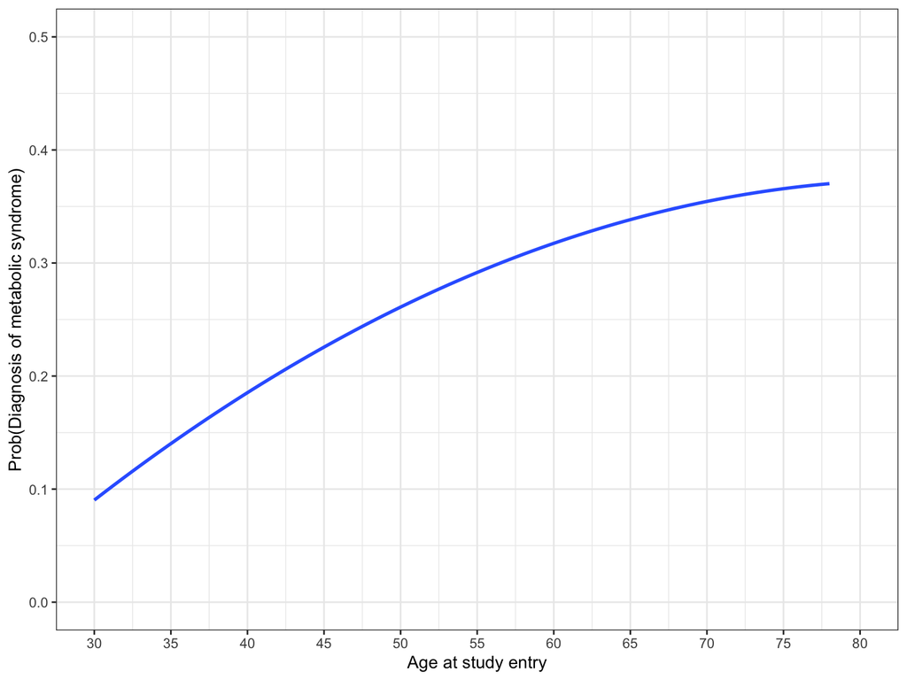

```r
dat_DmS_1 |>
  ggplot(aes(x=ageSE, y=DmS, group=1)) +
  geom_smooth(method="lm", formula=y~poly(x,2), se=FALSE) +
  scale_x_continuous("Age at study entry", breaks=seq(30,80, 5)) +
  scale_y_continuous("Prob(Diagnosis of metabolic syndrome)") +
  theme_bw() + theme(legend.position = "top") +
  coord_cartesian(xlim=c(30,80), ylim=c(0,.5))
```

### 3.4.2 *Post-hoc* LMM

```r
contrasts(dat_DmS_1$Sex) <- contr.sum(2)

m1b <- glmer(DmS ~ 1 + Sex/(y1 + y2) + a1  + a2 + (1 | Subj), data=dat_DmS_1,
            family = binomial(link="logit"),
            control=glmerControl(calc.derivs=FALSE))

print(summary(m1b),corr=FALSE)
```

```
Generalized linear mixed model fit by maximum likelihood (Laplace
  Approximation) [glmerMod]
 Family: binomial  ( logit )
Formula: DmS ~ 1 + Sex/(y1 + y2) + a1 + a2 + (1 | Subj)
   Data: dat_DmS_1
Control: glmerControl(calc.derivs = FALSE)

     AIC      BIC   logLik deviance df.resid
  2279.5   2331.8  -1130.8   2261.5     2448

Scaled residuals:
    Min      1Q  Median      3Q     Max
-1.7562 -0.3472 -0.2250 -0.1288  3.9950

Random effects:
 Groups Name        Variance Std.Dev.
 Subj   (Intercept) 3.581    1.892
Number of obs: 2457, groups:  Subj, 1084

Fixed effects:
               Estimate Std. Error z value Pr(>|z|)
(Intercept)  -1.1365169  0.1669783  -6.806 1.00e-11 ***
Sex1         -0.4106182  0.1305835  -3.144  0.00166 **
a1            0.0406985  0.0166721   2.441  0.01464 *
a2           -0.0012416  0.0009125  -1.361  0.17364
Sexfemale:y1  0.0516694  0.0103490   4.993 5.95e-07 ***
Sexmale:y1    0.0527125  0.0101135   5.212 1.87e-07 ***
Sexfemale:y2 -0.0023727  0.0012202  -1.945  0.05183 .
Sexmale:y2   -0.0058273  0.0011733  -4.966 6.82e-07 ***
---
Signif. codes:  0 '***' 0.001 '**' 0.01 '*' 0.05 '.' 0.1 ' ' 1
```

# 4 Varying covariates: `year` and `age`

## 4.1 Construct dataframe

- Criterion: `DmS` in year
- Constant covariates: `Sex` for `Subj`
- Varying covariate: `y1`, `y2`, `a1` , `a2` for `Subj`

```r
dat_age <-
  dat |> filter(Variable=="age") |>
  select(Subj, year, age=value)

dat_DmS_2 <-
  dat_DmS_1  |>
  select(-a1, -a2) |>
  left_join(dat_age, by=c("Subj", "year") ) |>
  mutate(a1 = age - 55,
         a2 = a1*a1) |>
  relocate(age:a2, .after=y2)


stview(dfSummary(dat_DmS_2))
```

```
Switching method to 'browser'
```

```
Output file written: /var/folders/nd/l59kkqd951xdb29k4rt4yzj80000gn/T//Rtmp2lr8cV/filec5cf5f984d80.html
```

## 4.2 Plots: Age effect at diagnosis (within-subject)

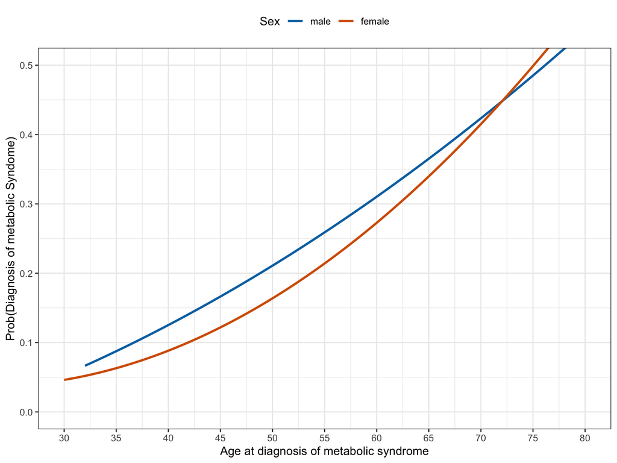

```r
dat_DmS_2 |>
  ggplot(aes(x=age, y=DmS, group=fct_rev(Sex), color=fct_rev(Sex))) +
  geom_smooth(method="lm", formula=y~poly(x,2), se=FALSE) +
  scale_x_continuous("Age at diagnosis of metabolic syndrome", breaks=seq(30,80, 5)) +
  scale_y_continuous("Prob(Diagnosis of metabolic Syndome)") +
  scale_color_manual("Sex", values=cbPalette) +
  theme_bw() + theme(legend.position = "top") +
  coord_cartesian(xlim=c(30,80), ylim=c(0,.5))
```

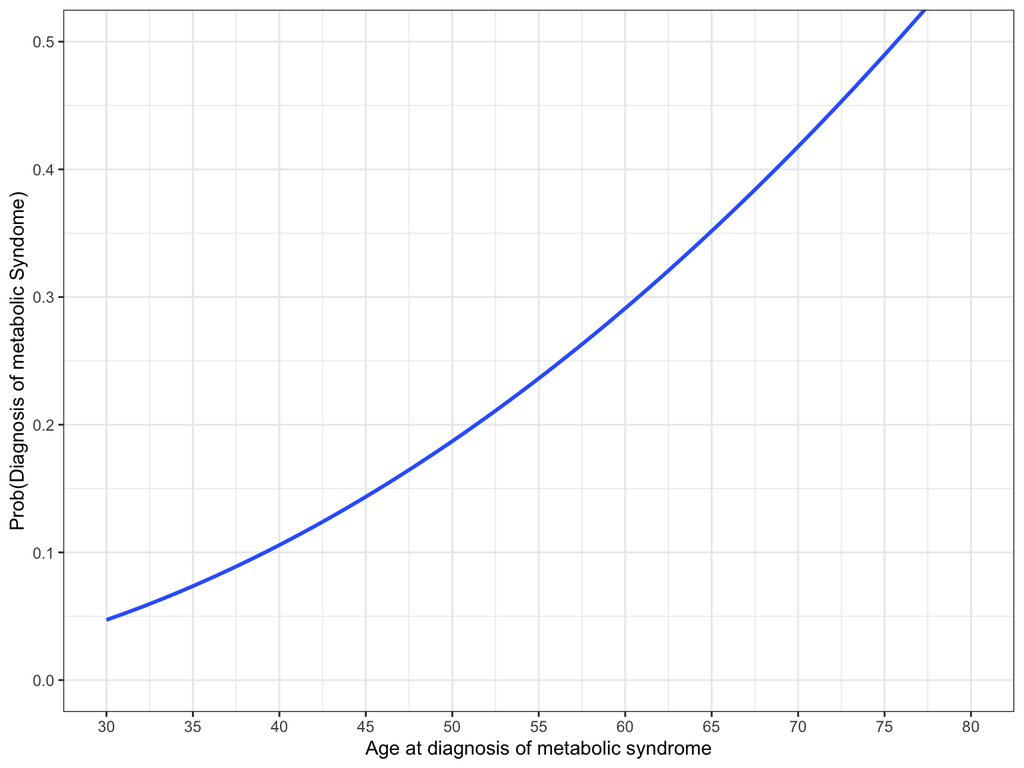

```r
dat_DmS_2 |>
  ggplot(aes(x=age, y=DmS, group=1)) +
  geom_smooth(method="lm", formula=y~poly(x,2), se=FALSE) +
  scale_x_continuous("Age at diagnosis of metabolic syndrome", breaks=seq(30,80, 5)) +
  scale_y_continuous("Prob(Diagnosis of metabolic Syndome)") +
  theme_bw() + theme(legend.position = "top") +
  coord_cartesian(xlim=c(30,80), ylim=c(0,.5))
```

## 4.3 Generalized LMM

- `Sex` is between-subject
- `age` is within-subject
- `year` is within-subject

```r
contrasts(dat_DmS_2$Sex) <- contr.sum(2)

m2 <- glmer(DmS ~ 1 + Sex*(y1 + y2) + a1  + a2 +  (1 | Subj), data=dat_DmS_2,
            family = binomial(link="logit"),
            control=glmerControl(calc.derivs=FALSE))

print(summary(m2),corr=FALSE)
```

```
Generalized linear mixed model fit by maximum likelihood (Laplace
  Approximation) [glmerMod]
 Family: binomial  ( logit )
Formula: DmS ~ 1 + Sex * (y1 + y2) + a1 + a2 + (1 | Subj)
   Data: dat_DmS_2
Control: glmerControl(calc.derivs = FALSE)

     AIC      BIC   logLik deviance df.resid
  2195.3   2247.6  -1088.7   2177.3     2448

Scaled residuals:
    Min      1Q  Median      3Q     Max
-2.4692 -0.3111 -0.2024 -0.1097  4.7817

Random effects:
 Groups Name        Variance Std.Dev.
 Subj   (Intercept) 3.994    1.998
Number of obs: 2457, groups:  Subj, 1084

Fixed effects:
              Estimate Std. Error z value Pr(>|z|)
(Intercept) -1.6497021  0.1463590 -11.272  < 2e-16 ***
Sex1        -0.3692407  0.1376042  -2.683 0.007289 **
y1          -0.0023193  0.0096686  -0.240 0.810427
y2          -0.0030330  0.0008706  -3.484 0.000495 ***
a1           0.0985485  0.0096224  10.242  < 2e-16 ***
a2           0.0002378  0.0005224   0.455 0.648959
Sex1:y1      0.0055886  0.0076423   0.731 0.464613
Sex1:y2      0.0018605  0.0008674   2.145 0.031969 *
---
Signif. codes:  0 '***' 0.001 '**' 0.01 '*' 0.05 '.' 0.1 ' ' 1
```

# 5 Varying covariates: `year`, `age`, `rfsum`, `sport`

## 5.1 Construct dataframe

- Criterion: `DmS` in year
- Constant covariates: `Sex` for `Subj`
- Varying covariate: `y1`, `y2`, `a1` , `rfsum`, `sport` for `Subj`
- 5.5 missing values for sport are replaced by median (81 minutes) (by subj)
- sport_l = log(sport+1), that is increase by 1 minute and take log
- reference value for risk factor and sport_l is 0.
- Question: Is DmS == 1, if rfsum >=3? and 0 else?

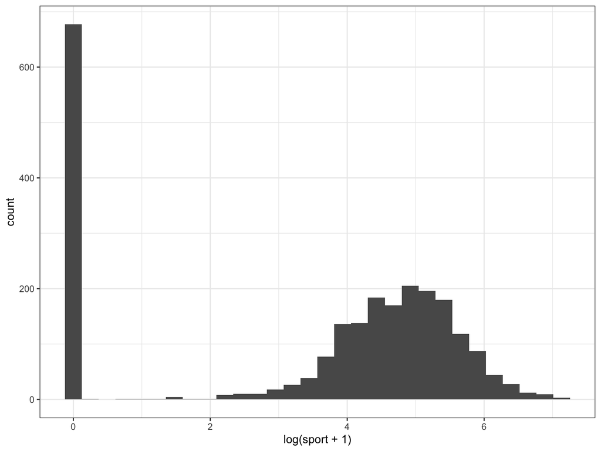

```r
dat_rf_sport <-
  dat |> filter(Variable=="rfsum" | Variable =="sport") |>
  select(Subj, year, Variable, value) |>
  pivot_wider(names_from="Variable", values_from = "value")

dat_rf_sport |>
  ggplot(aes(x=log(sport +1))) +
  geom_histogram() +  # geom_density
  theme_bw()
```

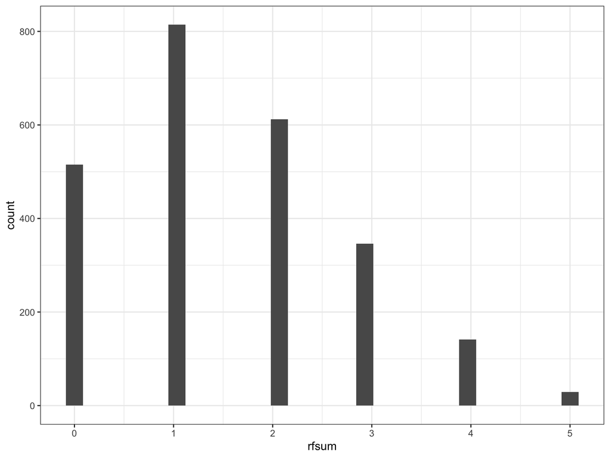

```r
dat_rf_sport |> ggplot(aes(x=rfsum)) + geom_histogram() + theme_bw()
```

```r
dat_DmS_3 <-
  dat_DmS_2  |>
  select(-a2) |>
  left_join(dat_rf_sport, by=c("Subj", "year") ) |>
  mutate(sport = ifelse(is.na(sport), 81, sport),
         sport_l = log(sport+1)) |>
  relocate(rfsum:sport_l, .after=a1)

stview(dfSummary(dat_DmS_3))
```

```
Switching method to 'browser'
```

```
Output file written: /var/folders/nd/l59kkqd951xdb29k4rt4yzj80000gn/T//Rtmp2lr8cV/filec5cf4f8709f0.html
```

## 5.2 Plot: Risk factor and time spent at sports at diagnosis (within-subject)

```r
tbl_rf <-
  dat_DmS_3 |>
  group_by(rfsum) |>
  summarise(N=n(), pDmS=sum(DmS)/N)
tbl_rf
```

```
# A tibble: 6 × 3
  rfsum     N  pDmS
  <dbl> <int> <dbl>
1     0   515     0
2     1   814     0
3     2   612     0
4     3   346     1
5     4   141     1
6     5    29     1
```

This looks like the `DmS` is determined by the number of risk factors (i.e., if `rfsum` >= 3, `DmS` == 1). We ignore it for present purposes and focus on `sport_l`.

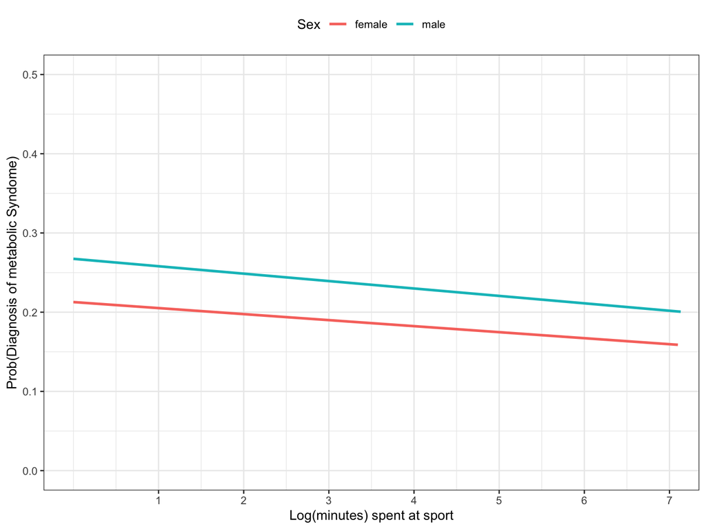

```r
dat_DmS_3 |>
  ggplot(aes(x=sport_l, y=DmS, group=Sex, color=Sex)) +
  geom_smooth(method="lm", formula=y~poly(x,1), se=FALSE) +
  scale_x_continuous("Log(minutes) spent at sport", breaks=1:7) +
  scale_y_continuous("Prob(Diagnosis of metabolic Syndome)") +
  theme_bw() + theme(legend.position = "top") +
  coord_cartesian(xlim=c(0, 7), ylim=c(0,.5))
```

## 5.3 Generalized LMM

- `Sex` is between-subject
- `age` is within-subject
- `year` is within-subject

```r
contrasts(dat_DmS_3$Sex) <- contr.sum(2)

m3 <- glmer(DmS ~ 1 + Sex*(y1 + y2 + sport_l) + a1  + sport_l +  (1 | Subj), data=dat_DmS_3,
            family = binomial(link="logit"),
            control=glmerControl(calc.derivs=FALSE))

print(summary(m3),corr=FALSE)
```

```
Generalized linear mixed model fit by maximum likelihood (Laplace
  Approximation) [glmerMod]
 Family: binomial  ( logit )
Formula: DmS ~ 1 + Sex * (y1 + y2 + sport_l) + a1 + sport_l + (1 | Subj)
   Data: dat_DmS_3
Control: glmerControl(calc.derivs = FALSE)

     AIC      BIC   logLik deviance df.resid
  2197.4   2255.5  -1088.7   2177.4     2447

Scaled residuals:
    Min      1Q  Median      3Q     Max
-2.4034 -0.3348 -0.2194 -0.1155  4.4639

Random effects:
 Groups Name        Variance Std.Dev.
 Subj   (Intercept) 3.283    1.812
Number of obs: 2457, groups:  Subj, 1084

Fixed effects:
               Estimate Std. Error z value Pr(>|z|)
(Intercept)  -1.2997273  0.1762637  -7.374 1.66e-13 ***
Sex1         -0.2282797  0.1762804  -1.295  0.19533
y1           -0.0008813  0.0093607  -0.094  0.92499
y2           -0.0031336  0.0008454  -3.706  0.00021 ***
sport_l      -0.0533099  0.0347363  -1.535  0.12486
a1            0.0972683  0.0091281  10.656  < 2e-16 ***
Sex1:y1       0.0060107  0.0075680   0.794  0.42706
Sex1:y2       0.0013763  0.0008441   1.630  0.10300
Sex1:sport_l -0.0142772  0.0346405  -0.412  0.68023
---
Signif. codes:  0 '***' 0.001 '**' 0.01 '*' 0.05 '.' 0.1 ' ' 1
```

No sport vs. sport?

```r
dat_DmS_3$sport2 <-  ifelse(dat_DmS_3$sport_l == 0, 0, 1)

m4 <- glmer(DmS ~ 1 + Sex*(y1 + y2 + sport2) + a1  +  (1 | Subj), data=dat_DmS_3,
            family = binomial(link="logit"),
            control=glmerControl(calc.derivs=FALSE))

print(summary(m4),corr=FALSE)
```

```
Generalized linear mixed model fit by maximum likelihood (Laplace
  Approximation) [glmerMod]
 Family: binomial  ( logit )
Formula: DmS ~ 1 + Sex * (y1 + y2 + sport2) + a1 + (1 | Subj)
   Data: dat_DmS_3
Control: glmerControl(calc.derivs = FALSE)

     AIC      BIC   logLik deviance df.resid
  2196.0   2254.1  -1088.0   2176.0     2447

Scaled residuals:
    Min      1Q  Median      3Q     Max
-2.5312 -0.3147 -0.2036 -0.1054  4.8274

Random effects:
 Groups Name        Variance Std.Dev.
 Subj   (Intercept) 3.907    1.976
Number of obs: 2457, groups:  Subj, 1084

Fixed effects:
              Estimate Std. Error z value Pr(>|z|)
(Intercept) -1.4861464  0.1909930  -7.781 7.19e-15 ***
Sex1        -0.4078603  0.1909744  -2.136 0.032705 *
y1           0.0002011  0.0098146   0.020 0.983652
y2          -0.0031905  0.0008729  -3.655 0.000257 ***
sport2      -0.1627446  0.1788607  -0.910 0.362878
a1           0.0971425  0.0096230  10.095  < 2e-16 ***
Sex1:y1      0.0067186  0.0078004   0.861 0.389068
Sex1:y2      0.0018159  0.0008714   2.084 0.037165 *
Sex1:sport2  0.0583533  0.1781503   0.328 0.743251
---
Signif. codes:  0 '***' 0.001 '**' 0.01 '*' 0.05 '.' 0.1 ' ' 1
```

```r
m4b <- glmer(DmS ~ 1 + Sex + sport2 + a1 +  (1 | Subj), data=dat_DmS_3,
            family = binomial(link="logit"),
            control=glmerControl(calc.derivs=FALSE))

print(summary(m4b),corr=FALSE)
```

```
Generalized linear mixed model fit by maximum likelihood (Laplace
  Approximation) [glmerMod]
 Family: binomial  ( logit )
Formula: DmS ~ 1 + Sex + sport2 + a1 + (1 | Subj)
   Data: dat_DmS_3
Control: glmerControl(calc.derivs = FALSE)

     AIC      BIC   logLik deviance df.resid
  2205.1   2234.1  -1097.5   2195.1     2452

Scaled residuals:
    Min      1Q  Median      3Q     Max
-2.6827 -0.3274 -0.1992 -0.1110  4.4131

Random effects:
 Groups Name        Variance Std.Dev.
 Subj   (Intercept) 3.857    1.964
Number of obs: 2457, groups:  Subj, 1084

Fixed effects:
             Estimate Std. Error z value Pr(>|z|)
(Intercept) -1.829852   0.154934 -11.811   <2e-16 ***
Sex1        -0.164595   0.097836  -1.682   0.0925 .
sport2      -0.163831   0.170895  -0.959   0.3377
a1           0.097089   0.007452  13.029   <2e-16 ***
---
Signif. codes:  0 '***' 0.001 '**' 0.01 '*' 0.05 '.' 0.1 ' ' 1
```

# 6 Varying covariates: `year`, `age`, five factors

## 6.1 Construct dataframe

- Criterion: `DmS` in year
- Constant covariates: `Sex` for `Subj`
- Varying covariate: `y1`, `y2`, `a1` , `DBch`, `DDbt`, `DTgl`, `DHDL` , `DBhd`
- Missing values assigned to 0: 1 obs for `DTgl`, 118 obs (4.8%) for `DBch`
- They are all numeric 0/1 indicators

```r
dat_factors <-
  dat |> filter(Variable %in% c("DBch", "DBhd", "DDbt", "DHDL", "DTgl")) |>
  select(Subj, year, Variable, value) |>
  pivot_wider(names_from="Variable", values_from = "value")

dat_DmS_4 <-
  dat_DmS_2  |>
  select(-a2) |>
  left_join(dat_factors, by=c("Subj", "year") ) |>
  mutate(DTgl = ifelse(is.na(DTgl), 0, DTgl),
         DBch = ifelse(is.na(DBch), 0, DBch)) |>
  relocate(DBhd:DBch, .after=a1)

stview(dfSummary(dat_DmS_4))
```

```
Switching method to 'browser'
```

```
Output file written: /var/folders/nd/l59kkqd951xdb29k4rt4yzj80000gn/T//Rtmp2lr8cV/filec5cf7c79008.html
```

## 6.2 Generalized LMM

- `Sex` is between-subject
- `age` is within-subject
- `year` is within-subject
- `DBch`, `DBhd`, `DDbt`, `DHDL`, `DTgl` are within-subject

```r
contrasts(dat_DmS_4$Sex) <- contr.sum(2)

m5 <- glmer(DmS ~ 1 + Sex*(y1 + y2) + a1 +
                      DBch + DBhd + DHDL + #DDbt + #DTgl +
                 (1 | Subj), data=dat_DmS_4,
            family = binomial(link="logit"),
            control=glmerControl(calc.derivs=FALSE))

print(summary(m5),corr=FALSE)
```

```
Generalized linear mixed model fit by maximum likelihood (Laplace
  Approximation) [glmerMod]
 Family: binomial  ( logit )
Formula: DmS ~ 1 + Sex * (y1 + y2) + a1 + DBch + DBhd + DHDL + (1 | Subj)
   Data: dat_DmS_4
Control: glmerControl(calc.derivs = FALSE)

     AIC      BIC   logLik deviance df.resid
   895.7    959.6   -436.9    873.7     2446

Scaled residuals:
    Min      1Q  Median      3Q     Max
-2.3568 -0.0503 -0.0194 -0.0009 12.4568

Random effects:
 Groups Name        Variance Std.Dev.
 Subj   (Intercept) 0.6465   0.8041
Number of obs: 2457, groups:  Subj, 1084

Fixed effects:
              Estimate Std. Error z value Pr(>|z|)
(Intercept) -1.183e+01  1.366e+00  -8.661  < 2e-16 ***
Sex1        -2.431e-01  1.665e-01  -1.460  0.14422
y1           2.485e-02  1.050e-02   2.366  0.01798 *
y2          -7.573e-03  1.196e-03  -6.331 2.43e-10 ***
a1           2.680e-02  9.663e-03   2.773  0.00555 **
DBch         5.993e+00  6.996e-01   8.567  < 2e-16 ***
DBhd         6.016e+00  7.354e-01   8.181 2.82e-16 ***
DHDL         7.547e+00  7.167e-01  10.530  < 2e-16 ***
Sex1:y1      2.074e-03  9.247e-03   0.224  0.82256
Sex1:y2     -3.954e-05  1.190e-03  -0.033  0.97350
---
Signif. codes:  0 '***' 0.001 '**' 0.01 '*' 0.05 '.' 0.1 ' ' 1
```

**Results**

- `DTgl` is problematic – perhaps because not assessed initially
- Any three of the other four generate huge effects
- Sex main effect and interaction with year are no longer significant

# 7 Summary

Of course, the same script could be adjusted to use the measures instead of the diagnoses as predictors.

# 8 Appendix